# "데이터마이닝 기말 프로젝트"

> "해외축구선수 EDA 및 이적료 예측 모델링"
- toc: false
- branch: master
- badges: true
- comments: true
- author: Chanseong Park
- categories: [colaboratory, python]

### 해외축구선수 데이터 분석 및 이적료 예측 모델링

- 분석 동기 및 데이터 설명
  - 분석 동기
  - 데이터 설명
- 데이터 전처리
  - 데이터 구조 파악 및 변수형 파악
  - 변수 형태 파악
  - 범주형 변수 개체 확인
  - 파생변수 생성
  - 결측치 여부 파악
  - 이상치 여부 파악
  - 데이터 스케일링
- 탐색적데이터분석
  - 기초통계량 확인
  - 변수의 분포 확인
  - 시각화를 통한 인사이트 도출 및 검증
  - 상관분석
- 데이터 모델링
  - 다중회귀분석(모든변수, stepwise, 후진제거법)
    - 모든 변수를 사용한 다중회귀분석
    - 후진제거법을 사용한 다중회귀분석
    - 단계적선택법을 사용한 다중회귀분석
    - 결론
  - 다중회귀분석(Lasso)
    - 결론
  - 머신러닝 기법
    - VotingRegressor
    - ExtraTreesRegressor
    - NGBRegressor
    - GradientBoostRegressor
    - XGBRegressor
    - LGBMRegressor
    - CatBoostRegressor
    - 최종 예측값 생성
- 결론
  - 모델링 결론
  - 분석에서 아쉬웠던 점

## 분석 동기 및 데이터 설명

- 분석 동기
- 데이터 설명

### 분석 동기

해외축구선수 이적료 예측이라는 분석 주제를 선정한 이유는 필자는 스포츠 경기 보는 것을 좋아했었고 예전부터 스포츠 데이터 분석에 관심이 있었는데 축구선수 이적료 예측이라는 좋은 주제와 데이터가 데이콘에 있어서 주제로 선택해보았다.

분석 순서는 데이터 설명 -> 데이터 전처리 -> 탐색적 데이터 분석 -> 데이터 모델링 순으로 이루어져 있다. 각 분석과정에서 수행한 분석은 아래와 같다.

**데이터 설명**

- 분석 동기
- 데이터 설명

**데이터 전처리**

- 데이터 구조 파악 및 변수형 파악
- 변수 형태 파악
- 범주형 변수 개체 확인
- 파생변수 생성
- 결측치 여부 파악
- 이상치 여부 파악
- 데이터 스케일링

**탐색적 데이터 분석**

- 기초통계량 확인
- 변수의 분포 확인
- 시각화를 통한 인사이트 도출 및 검증
- 상관분석

**데이터 모델링**

- 회귀분석
- Lasso 회귀분석
- 머신러닝

### 데이터 설명

- 데이터는 train data와 test data가 분리된 채로 제공이 되며, train data는 설명변수 11개, 타겟변수 1개로 이루어져 있으며 test data는 설명변수 11개로 이루어져 있다.

**설명변수**

- ID: 선수 고유의 아이디
- Name: 선수의 이름
- Age: 선수의 나이
- Continent: 선수들의 국적이 포함되어있는 대륙
- Countract_until: 선수의 계약기간(연도)
- Position: 선수가 선호하는 포지션
- Prefer_foot: 선수가 선호하는 발
- Reputation: 선수의 명성
- Stat_overall: 선수의 현재 능력치
- Stat_potential: 선수의 발전가능성
- Stat_skill_moves: 선수의 개인기 능력

**타겟변수**

- Value: 피파가 선정한 선수의 이적료

## 데이터 전처리

- 데이터 구조 및 변수형 파악
- 변수형태 파악
- 범주형 변수 개체 확인
- 파생변수 생성
- 결측치 여부 확인
- 이상치 여부 확인
- 데이터 스케일링

### 데이터 구조 및 변수형 파악

- 데이터 제공 년도 2018

```python
cd drive/My Drive/22-1_데이터마이닝/기말발표/피파 데이터
```

```python
import pandas as pd
import numpy as np
import matplotlib.pyplot as plt
import seaborn as sns
```

```python
train = pd.read_csv("FIFA_train.csv")
train = train.iloc[:,1:] #필요없는 id열 제거
train = train.set_index("name") # 인덱스 이름으로 설정
```

```python
test = pd.read_csv("FIFA_test.csv")
test = test.iloc[:,1:] #필요없는 id열 제거
test = test.set_index("name") # 인덱스 이름으로 설정
```

```python
test.head()
```

| name | age | continent | contract_until | position | prefer_foot | reputation | stat_overall | stat_potential | stat_skill_moves |
| --- | --- | --- | --- | --- | --- | --- | --- | --- | --- |
| Cristiano Ronaldo | 33 | europe | 2022 | ST | right | 5.0 | 94 | 94 | 5.0 |
| Neymar Jr | 26 | south america | 2022 | ST | right | 5.0 | 92 | 93 | 5.0 |
| K. De Bruyne | 27 | europe | 2023 | MF | right | 4.0 | 91 | 92 | 4.0 |
| E. Hazard | 27 | europe | 2020 | ST | right | 4.0 | 91 | 91 | 4.0 |
| L. Modrić | 32 | europe | 2020 | MF | right | 4.0 | 91 | 91 | 4.0 |

```python
# 데이터 구조 파악

print(train.shape,"\n") # 8932행 10열
print(test.shape) # 3828행 9열
```

```
(8932, 10)

(3828, 9)
```

### 변수 형태 파악

- 설명변수는 변수 형태는 연속형 5개, 범주형 4개로 이루어져있다.
- 타겟변수는 연속형 변수이다.

```python
print(train.info(),"\n\n")
print(test.info())
```

```
<class 'pandas.core.frame.DataFrame'>
Index: 8932 entries, L. Messi to N. Christoffersson
Data columns (total 10 columns):
 #   Column            Non-Null Count  Dtype
---  ------            --------------  -----
 0   age               8932 non-null   int64
 1   continent         8932 non-null   object
 2   contract_until    8932 non-null   object
 3   position          8932 non-null   object
 4   prefer_foot       8932 non-null   object
 5   reputation        8932 non-null   float64
 6   stat_overall      8932 non-null   int64
 7   stat_potential    8932 non-null   int64
 8   stat_skill_moves  8932 non-null   float64
 9   value             8932 non-null   float64
dtypes: float64(3), int64(3), object(4)
memory usage: 767.6+ KB
None


<class 'pandas.core.frame.DataFrame'>
Index: 3828 entries, Cristiano Ronaldo to K. Fujikawa
Data columns (total 9 columns):
 #   Column            Non-Null Count  Dtype
---  ------            --------------  -----
 0   age               3828 non-null   int64
 1   continent         3828 non-null   object
 2   contract_until    3828 non-null   object
 3   position          3828 non-null   object
 4   prefer_foot       3828 non-null   object
 5   reputation        3828 non-null   float64
 6   stat_overall      3828 non-null   int64
 7   stat_potential    3828 non-null   int64
 8   stat_skill_moves  3828 non-null   float64
dtypes: float64(2), int64(3), object(4)
memory usage: 299.1+ KB
None
```

### 범주형 변수 개체 확인

```python
# 범주형 변수 개체 확인

print("continent :", train["continent"].unique(),"\n")
print("contract_util :",  train["contract_until"].unique(),"\n")
print("position :", train["position"].unique(),"\n")
print("prefer_foot :", train["prefer_foot"].unique(),"\n")
print("continent :", test["continent"].unique(),"\n")
print("contract_util :", test["contract_until"].unique(),"\n")
print("position :", test["position"].unique(),"\n")
print("prefer_foot :", test["prefer_foot"].unique(),"\n")

# 계약기간 변수가 이상하다. 날짜로 되어있는 데이터를 비율에 맞춰 연도와 같은 단위로 바꿔준다.
```

```
continent : ['south america' 'europe' 'africa' 'asia' 'oceania']

contract_util : ['2021' '2020' '2019' '2023' '2022' '2024' 'Jun 30, 2019' '2026'
 'Dec 31, 2018' '2018' '2025' 'Jun 30, 2020' 'May 31, 2020' 'May 31, 2019'
 'Jan 31, 2019' 'Jan 1, 2019' 'Jan 12, 2019']

position : ['ST' 'GK' 'DF' 'MF']

prefer_foot : ['left' 'right']

continent : ['europe' 'south america' 'africa' 'asia' 'oceania']

contract_util : ['2022' '2023' '2020' '2021' 'Jun 30, 2019' '2019' '2025' '2024' '2018'
 'May 31, 2020' 'Jun 30, 2020' 'May 31, 2019' 'Dec 31, 2019'
 'Dec 31, 2018' 'Jun 1, 2019' 'Jan 1, 2019' 'Jan 31, 2019' '2026']

position : ['ST' 'MF' 'DF' 'GK']

prefer_foot : ['right' 'left']
```

```python
# 데이터 개체수 확인
pd.value_counts(train["reputation"])
```

```
1.0    8014
2.0     706
3.0     177
4.0      31
5.0       4
Name: reputation, dtype: int64
```

계약기간 변수의 단위가 연도가 아닌 연월일로 이루어진 데이터들이 있어서 같은 단위로 변환해주었다.

```python
# 연도가 아닌 날짜로 나와있는 계약기간을 연도로 변환(소수점 둘째자리까지)

train["contract_until"][(train["contract_until"] == "Jun 30, 2020")] = '2020.5'
train["contract_until"][(train["contract_until"] == "Jun 30, 2019")] = '2019.5'
train["contract_until"][(train["contract_until"] == "May 31, 2020")] = '2020.42'
train["contract_until"][(train["contract_until"] == "May 31, 2019")] = '2019.42'
train["contract_until"][(train["contract_until"] == "Dec 31, 2019")] = '2020'
train["contract_until"][(train["contract_until"] == "Dec 31, 2018")] = '2019'
train["contract_until"][(train["contract_until"] == "Jun 1, 2019")] = '2019'
train["contract_until"][(train["contract_until"] == "Jan 1, 2019")] = '2019'
train["contract_until"][(train["contract_until"] == "Jan 31, 2019")] = '2019.08'
train["contract_until"][(train["contract_until"] == "Jan 12, 2019")] = '2019.03'
```

```python
# 연도가 아닌 날짜로 나와있는 계약기간을 연도로 변환(소수점 둘째자리까지)

test["contract_until"][(test["contract_until"] == "Jun 30, 2020")] = '2020.5'
test["contract_until"][(test["contract_until"] == "Jun 30, 2019")] = '2019.5'
test["contract_until"][(test["contract_until"] == "May 31, 2020")] = '2020.42'
test["contract_until"][(test["contract_until"] == "May 31, 2019")] = '2019.42'
test["contract_until"][(test["contract_until"] == "Dec 31, 2019")] = '2020'
test["contract_until"][(test["contract_until"] == "Dec 31, 2018")] = '2019'
test["contract_until"][(test["contract_until"] == "Jun 1, 2019")] = '2019'
test["contract_until"][(test["contract_until"] == "Jan 1, 2019")] = '2019'
test["contract_until"][(test["contract_until"] == "Jan 31, 2019")] = '2019.08'
test["contract_until"][(test["contract_until"] == "Jan 12, 2019")] = '2019.03'
```

```python
# 계약기간의 변환이 잘 이루어졌음을 확인할 수 있다.

print(train["contract_until"].unique(),"\n")
print(train["contract_until"].unique())
```

```
['2021' '2020' '2019' '2023' '2022' '2024' '2019.5' '2026' '2018' '2025'
 '2020.5' '2020.42' '2019.42' '2019.08' '2019.03']

['2021' '2020' '2019' '2023' '2022' '2024' '2019.5' '2026' '2018' '2025'
 '2020.5' '2020.42' '2019.42' '2019.08' '2019.03']
```

### 파생변수 생성

- 계약기간 변수를 활용하여 연속형 변수인 남은 계약기간 변수로 만들어주었고 원래의 계약기간 변수는 삭제해주었다.

```python
# 파생변수 생성
# 범주형 변수인 계약기간 변수에서 2018을 빼줘서 잔여계약연수라는 변수를 새로 만들어준다. 만든 후 계약기간 변수는 삭제해준다.

train["new_contract"] = train["contract_until"].astype("float") - 2018
test["new_contract"] = test["contract_until"].astype("float") - 2018

#계약기간 변수 삭제

train = train.drop("contract_until",axis=1)
test = test.drop("contract_until",axis=1)

#기존 계약변수는 삭제되고 새로운 계약변수가 삽입되었음을 알 수 있다.

print(train.info() , "\n\n")
print(test.info())
```

```
<class 'pandas.core.frame.DataFrame'>
Index: 8932 entries, L. Messi to N. Christoffersson
Data columns (total 10 columns):
 #   Column            Non-Null Count  Dtype
---  ------            --------------  -----
 0   age               8932 non-null   int64
 1   continent         8932 non-null   object
 2   position          8932 non-null   object
 3   prefer_foot       8932 non-null   object
 4   reputation        8932 non-null   float64
 5   stat_overall      8932 non-null   int64
 6   stat_potential    8932 non-null   int64
 7   stat_skill_moves  8932 non-null   float64
 8   value             8932 non-null   float64
 9   new_contract      8932 non-null   float64
dtypes: float64(4), int64(3), object(3)
memory usage: 767.6+ KB
None


<class 'pandas.core.frame.DataFrame'>
Index: 3828 entries, Cristiano Ronaldo to K. Fujikawa
Data columns (total 9 columns):
 #   Column            Non-Null Count  Dtype
---  ------            --------------  -----
 0   age               3828 non-null   int64
 1   continent         3828 non-null   object
 2   position          3828 non-null   object
 3   prefer_foot       3828 non-null   object
 4   reputation        3828 non-null   float64
 5   stat_overall      3828 non-null   int64
 6   stat_potential    3828 non-null   int64
 7   stat_skill_moves  3828 non-null   float64
 8   new_contract      3828 non-null   float64
dtypes: float64(3), int64(3), object(3)
memory usage: 299.1+ KB
None
```

```python
print(train.new_contract.describe(),"\n")
print("new_contract :", list(train.new_contract.unique()))
```

```
count    8932.000000
mean        2.231105
std         1.234711
min         0.000000
25%         1.000000
50%         2.000000
75%         3.000000
max         8.000000
Name: new_contract, dtype: float64

new_contract : [3.0, 2.0, 1.0, 5.0, 4.0, 6.0, 1.5, 8.0, 0.0, 7.0, 2.5, 2.4200000000000728, 1.4200000000000728, 1.0799999999999272, 1.0299999999999727]
```

### 결측치 여부 파악

- 데이터에 결측치는 존재하지 않았다.

```python
# 변수에 결측치 여부 확인하기

print(train.isna().sum(),"\n")
print(test.isna().sum())

# 전체 데이터에 결측치가 존재하지 않음을 알 수 있다.
```

```
age                 0
continent           0
position            0
prefer_foot         0
reputation          0
stat_overall        0
stat_potential      0
stat_skill_moves    0
value               0
new_contract        0
dtype: int64

age                 0
continent           0
position            0
prefer_foot         0
reputation          0
stat_overall        0
stat_potential      0
stat_skill_moves    0
new_contract        0
dtype: int64
```

### 이상치 여부 파악

- 이상치 기준은 평균에서 3시그마 이상 떨어진 값으로 규정하였다.
- 명성 변수와 이적료 변수는 한쪽으로 상당히 치우쳐져있어 이상치를 제거하면 다량의 정보손실을 가져오기 때문에 이상치 기준에서 제외하였다.
- 이상치를 제외하여 분석하였지만 예측모델의 정확도는 좋지 않았다.
- 이상치를 제외한 예측모델의 정확도가 좋지 않은 이유는 변수들의 이상치 기준이 해외축구에서 충분히 가능한 정도이고 test data에도 이러한 이상치들이 포함되어 있을 것이라고 판단하였고, 이상치를 포함하여 분석을 시행하기로 결정하였다.

```python
print(np.mean(train) + 3*np.std(train))
print(np.mean(train) - 3*np.std(train))
```

```
age                 3.911490e+01
reputation          2.402182e+00
stat_overall        8.765471e+01
stat_potential      8.996064e+01
stat_skill_moves    4.729714e+00
value               2.030064e+07
new_contract        5.935032e+00
dtype: float64
age                 1.130337e+01
reputation         -1.404268e-01
stat_overall        4.652755e+01
stat_potential      5.403377e+01
stat_skill_moves    7.368917e-02
value              -1.474329e+07
new_contract       -1.472822e+00
dtype: float64
```

```python
'''
이상치 제거 후 모델링을 수행하였지만 결과가 처참하였다. 이는 test data에도 3sigma를 벗어나는 값들이 다수 존재하고 벗어난 값 역시 충분히 가능한 수치이기 때문이라고 판단하여
이상치 제거를 하지 않는 방향으로 설정하였다.

train = train[(train.age < np.mean(train.age)+3*np.std(train.age)) & (train.age > np.mean(train.age)-3*np.std(train.age))]
train = train[(train.stat_overall < np.mean(train.stat_overall)+3*np.std(train.stat_overall)) & (train.stat_overall> np.mean(train.stat_overall)-3*np.std(train.stat_overall))]
train = train[(train.stat_potential < np.mean(train.stat_potential)+3*np.std(train.stat_potential)) & (train.stat_potential > np.mean(train.stat_potential)-3*np.std(train.stat_potential))]
train = train[(train.stat_skill_moves < np.mean(train.stat_skill_moves)+3*np.std(train.stat_skill_moves)) & (train.age > np.mean(train.stat_skill_moves)-3*np.std(train.stat_skill_moves))]
train = train[(train.new_contract < np.mean(train.new_contract)+3*np.std(train.new_contract)) & (train.new_contract > np.mean(train.new_contract)-3*np.std(train.new_contract))]

# 8932 -> 8839개로 줄었다.
train.shape
'''
```

### 데이터 스케일링

- 연속형 데이터의 범위가 유사할수록 모델의 정확도는 올라간다.
- 데이터를 설명변수와 타겟변수로 분할한 후 연속형 변수에 대한 데이터 스케일링을 수행하였다.

```python
# train 데이터 X(설명변수), y(타겟변수)로 분할

X_train = train.drop("value",axis=1)
y_train = train[["value"]]
```

```python
print(X_train.info())
print(test.info())
```

```
<class 'pandas.core.frame.DataFrame'>
Index: 8932 entries, L. Messi to N. Christoffersson
Data columns (total 9 columns):
 #   Column            Non-Null Count  Dtype
---  ------            --------------  -----
 0   age               8932 non-null   int64
 1   continent         8932 non-null   object
 2   position          8932 non-null   object
 3   prefer_foot       8932 non-null   object
 4   reputation        8932 non-null   float64
 5   stat_overall      8932 non-null   int64
 6   stat_potential    8932 non-null   int64
 7   stat_skill_moves  8932 non-null   float64
 8   new_contract      8932 non-null   float64
dtypes: float64(3), int64(3), object(3)
memory usage: 697.8+ KB
None
<class 'pandas.core.frame.DataFrame'>
Index: 3828 entries, Cristiano Ronaldo to K. Fujikawa
Data columns (total 9 columns):
 #   Column            Non-Null Count  Dtype
---  ------            --------------  -----
 0   age               3828 non-null   int64
 1   continent         3828 non-null   object
 2   position          3828 non-null   object
 3   prefer_foot       3828 non-null   object
 4   reputation        3828 non-null   float64
 5   stat_overall      3828 non-null   int64
 6   stat_potential    3828 non-null   int64
 7   stat_skill_moves  3828 non-null   float64
 8   new_contract      3828 non-null   float64
dtypes: float64(3), int64(3), object(3)
memory usage: 299.1+ KB
None
```

```python
# 데이터 스케일링
# 연속형 데이터의 범위가 비슷할수록 정확도가 올라간다.

from sklearn.preprocessing import StandardScaler
scaler = StandardScaler()

Xtr_scaled = scaler.fit_transform(X_train.iloc[:,[0,4,5,6,7,8]])
Xte_scaled = scaler.transform(test.iloc[:,[0,4,5,6,7,8]]) #X_train scaling fit으로 스케일링 해준다.

#array -> dataframe
Xtr_scaled = pd.DataFrame(Xtr_scaled,columns = ["age_scaled","reputation_scaled","overall_scaled","potential_scaled","skill_scaled","contract_scaled"],index = X_train.index)
Xte_scaled = pd.DataFrame(Xte_scaled,columns = ["age_scaled","reputation_scaled","overall_scaled","potential_scaled","skill_scaled","contract_scaled"],index = test.index)

# 범주형 변수와 다시 결합
X_train = pd.concat([X_train.iloc[:,[1,2,3]],Xtr_scaled],axis=1)
X_test = pd.concat([test.iloc[:,[1,2,3]],Xte_scaled],axis=1)

#데이터가 잘 붙었음을 알 수 있다.
print(X_train.info() , "\n\n")
print(X_test.info())
```

```
<class 'pandas.core.frame.DataFrame'>
Index: 8932 entries, L. Messi to N. Christoffersson
Data columns (total 9 columns):
 #   Column             Non-Null Count  Dtype
---  ------             --------------  -----
 0   continent          8932 non-null   object
 1   position           8932 non-null   object
 2   prefer_foot        8932 non-null   object
 3   age_scaled         8932 non-null   float64
 4   reputation_scaled  8932 non-null   float64
 5   overall_scaled     8932 non-null   float64
 6   potential_scaled   8932 non-null   float64
 7   skill_scaled       8932 non-null   float64
 8   contract_scaled    8932 non-null   float64
dtypes: float64(6), object(3)
memory usage: 697.8+ KB
None


<class 'pandas.core.frame.DataFrame'>
Index: 3828 entries, Cristiano Ronaldo to K. Fujikawa
Data columns (total 9 columns):
 #   Column             Non-Null Count  Dtype
---  ------             --------------  -----
 0   continent          3828 non-null   object
 1   position           3828 non-null   object
 2   prefer_foot        3828 non-null   object
 3   age_scaled         3828 non-null   float64
 4   reputation_scaled  3828 non-null   float64
 5   overall_scaled     3828 non-null   float64
 6   potential_scaled   3828 non-null   float64
 7   skill_scaled       3828 non-null   float64
 8   contract_scaled    3828 non-null   float64
dtypes: float64(6), object(3)
memory usage: 299.1+ KB
None
```

## 탐색적 데이터분석

- 기초통계량 확인
- 변수의 분포 파악
- 시각화를 통한 인사이트 발견
- 인사이트 검증
- 설명변수와 타겟변수 간의 상관분석

### 기초통계량 확인

```python
# 기초통계량 확인

X_train.describe()
```

|  | age_scaled | reputation_scaled | overall_scaled | potential_scaled | skill_scaled | contract_scaled |
| --- | --- | --- | --- | --- | --- | --- |
| count | 8.932000e+03 | 8.932000e+03 | 8.932000e+03 | 8.932000e+03 | 8.932000e+03 | 8.932000e+03 |
| mean | -7.886611e-15 | 4.642888e-14 | 3.397292e-15 | -1.529353e-16 | -1.110065e-14 | 3.471106e-15 |
| std | 1.000056e+00 | 1.000056e+00 | 1.000056e+00 | 1.000056e+00 | 1.000056e+00 | 1.000056e+00 |
| min | -1.986759e+00 | -3.088428e-01 | -2.931075e+00 | -4.007675e+00 | -1.806307e+00 | -1.807086e+00 |
| 25% | -9.080698e-01 | -3.088428e-01 | -5.968513e-01 | -6.675562e-01 | -5.176541e-01 | -9.971350e-01 |
| 50% | -4.511848e-02 | -3.088428e-01 | -1.329530e-02 | 4.674371e-04 | -5.176541e-01 | -1.871838e-01 |
| 75% | 6.020950e-01 | -3.088428e-01 | 7.161497e-01 | 6.684911e-01 | 7.709987e-01 | 6.227674e-01 |
| max | 3.190949e+00 | 9.130280e+00 | 3.925708e+00 | 3.674598e+00 | 3.348304e+00 | 4.672523e+00 |

```python
X_test.describe() # train과 test 데이터의 분포가 유사함을 알 수 있다.
```

|  | age_scaled | reputation_scaled | overall_scaled | potential_scaled | skill_scaled | contract_scaled |
| --- | --- | --- | --- | --- | --- | --- |
| count | 3828.000000 | 3828.000000 | 3828.000000 | 3828.000000 | 3828.000000 | 3828.000000 |
| mean | 0.019129 | 0.030823 | 0.035868 | 0.018442 | 0.016928 | 0.034338 |
| std | 0.998486 | 1.058279 | 1.007920 | 1.024319 | 1.006635 | 1.025627 |
| min | -1.986759 | -0.308843 | -2.931075 | -3.339651 | -1.806307 | -1.807086 |
| 25% | -0.692332 | -0.308843 | -0.596851 | -0.667556 | -0.517654 | -0.997135 |
| 50% | -0.045118 | -0.308843 | -0.013295 | 0.000467 | -0.517654 | -0.187184 |
| 75% | 0.817833 | -0.308843 | 0.716150 | 0.668491 | 0.770999 | 0.622767 |
| max | 3.622425 | 9.130280 | 3.925708 | 3.841604 | 3.348304 | 4.672523 |

### 변수의 분포 확인

- 분포 시각화 결과 reputation_scaled, value 변수의 좌로 치우침이 심한 것으로 보인다.
- 로그 변환을 통해 분포를 안정화 시켜주었다.

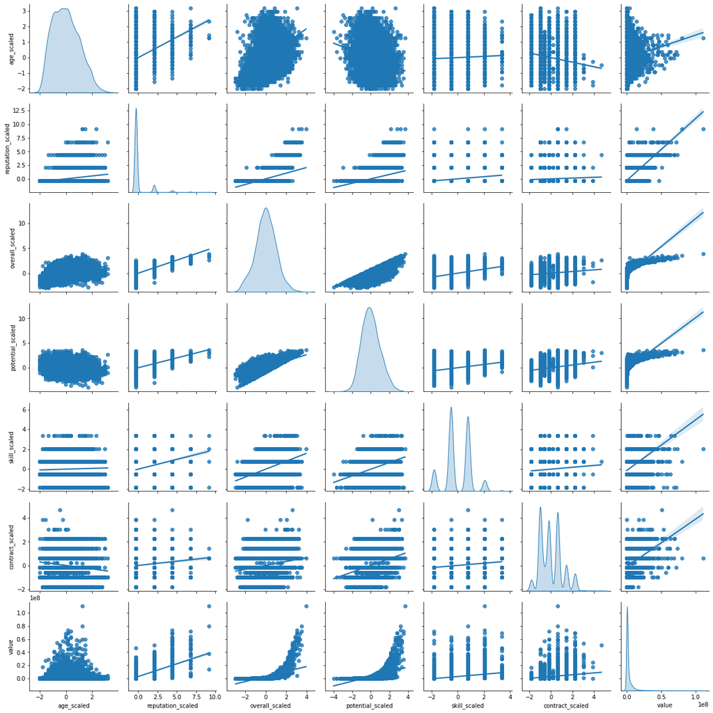

```python
# 변수의 분포 확인
sns.pairplot(pd.concat([X_train,y_train],axis=1),kind="reg",diag_kind="kde")
plt.show()
```

```python
numerical_feats_X = X_train.dtypes[X_train.dtypes != "object"].index

for col in numerical_feats_X:
  print('{:15}'.format(col),
        'Skewness: {:05.2f}'.format(X_train[col].skew()) ,
        ' ' ,
        'Kurtosis: {:06.2f}'.format(X_train[col].kurt()) )

# 산점도와 왜도, 첨도를 계산해보니 reputatio_scaled 변환이 필요해보인다.
```

```
age_scaled      Skewness: 00.36   Kurtosis: -00.53
reputation_scaled Skewness: 03.77   Kurtosis: 016.32
overall_scaled  Skewness: 00.03   Kurtosis: 000.11
potential_scaled Skewness: 00.29   Kurtosis: 000.06
skill_scaled    Skewness: 00.09   Kurtosis: -00.16
contract_scaled Skewness: 00.52   Kurtosis: -00.26
```

```python
numerical_feats_y = y_train.dtypes[y_train.dtypes != "object"].index

for col in numerical_feats_y:
  print('{:15}'.format(col),
        'Skewness: {:05.2f}'.format(y_train[col].skew()) ,
        ' ' ,
        'Kurtosis: {:06.2f}'.format(y_train[col].kurt()) )

# value의 왜도를 보니 좌측으로 심하게 치우쳐있다.
# 로그변환을 취해준다.
```

```
value           Skewness: 05.89   Kurtosis: 052.05
```

```python
# reputation_scaled에 로그변환을 취했을때 왜도와 첨도가 줄었으니 로그변환을 취해준다.
print("skew : ",np.log1p(X_train[["reputation_scaled"]]).skew())
print("skew : ",np.log1p(X_train[["reputation_scaled"]]).kurt())
```

```
skew :  reputation_scaled    2.795525
dtype: float64
skew :  reputation_scaled    6.313924
dtype: float64
```

```python
#value에 로그변환을 취했을때 왜도와 첨도가 확연하게 줄어들었다.
print("skew : ",np.log1p(y_train[["value"]]).skew())
print("kert : ",np.log1p(y_train[["value"]]).kurt())
```

```
skew :  value    0.308798
dtype: float64
kert :  value   -0.199544
dtype: float64
```

```python
X_train["reputation_scaled"] = np.log1p(X_train[["reputation_scaled"]])
X_test["reputation_scaled"] = np.log1p(X_test[["reputation_scaled"]])

print(pd.value_counts(X_train["reputation_scaled"]),"\n")
print(pd.value_counts(X_test["reputation_scaled"]),"\n")
```

```
-0.369388    8014
 1.115449     706
 1.688382     177
 2.050334      31
 2.315529       4
Name: reputation_scaled, dtype: int64

-0.369388    3402
 1.115449     323
 1.688382      83
 2.050334      18
 2.315529       2
Name: reputation_scaled, dtype: int64
```

```python
y_train["value"] = np.log1p(y_train[["value"]])
y_train["value"]
```

```
name
L. Messi              18.520526
De Gea                18.092177
L. Suárez             18.197537
Sergio Ramos          17.747336
J. Oblak              18.035018
                        ...
S. Adewusi            11.002117
C. Ehlich             10.596660
N. Fuentes            10.819798
J. Milli              10.819798
N. Christoffersson    11.002117
Name: value, Length: 8932, dtype: float64
```

### 시각화를 통한 인사이트 도출 및 검증

```python
# 범주형 변수 별 이적료 시각화(대륙별)
import plotly.express as px
fig = px.box(train,x='continent',y="value",points="all",notched=True,color="continent")
fig.show()
```

[interactive chart not shown]

```python
#다중비교(대륙별)
from statsmodels.stats.multicomp import pairwise_tukeyhsd
from statsmodels.stats.multicomp import MultiComparison
mc = MultiComparison(train['value'],train['continent'])
mc_results = mc.tukeyhsd()
print(mc_results)
```

```
             Multiple Comparison of Means - Tukey HSD, FWER=0.05
=============================================================================
 group1     group2       meandiff   p-adj      lower         upper     reject
-----------------------------------------------------------------------------
 africa          asia -1937100.7548  0.001  -2754054.033 -1120147.4766   True
 africa        europe   -44122.1142    0.9  -673009.3458   584765.1174  False
 africa       oceania -2149704.0222  0.001 -3485127.1572  -814280.8872   True
 africa south america   210957.5836    0.9  -480876.6503   902791.8174  False
   asia        europe  1892978.6406  0.001  1287760.6785  2498196.6027   True
   asia       oceania  -212603.2674    0.9 -1537044.5009  1111837.9662  False
   asia south america  2148058.3384  0.001  1477667.2296  2818449.4472   True
 europe       oceania  -2105581.908  0.001 -3323051.0338  -888112.7821   True
 europe south america   255079.6978 0.4655  -166240.5249   676399.9204  False
oceania south america  2360661.6058  0.001  1109515.5194  3611807.6921   True
-----------------------------------------------------------------------------
```

- 시각적으로 보았을때는 남미, 유럽, 아프리카는 비슷한 분포를 띄고 아시아와 오세아니아는 앞의 세 나라와 이적료의 차이가 유의미해 보인다.
- tukey 다중비교 분석을 수행한 결과 박스플롯 그래프를 보고 판단했을때처럼 유럽, 남미, 아프리카 선수의 이적료와 아시아, 오세아니아 선수의 이적료는 유의미한 차이가 있다.
- 대륙 변수는 이적료를 예측하는데 중요한 변수임을 알 수 있었다.

```python
# 범주형 변수 별 이적료 시각화(포지션 별)
fig = px.box(train,x='position',y="value",points="all",notched=True,color="position")
fig.show()
```

[interactive chart not shown]

```python
#다중비교(포지션별)
mc = MultiComparison(train['value'],train['position'])
mc_results = mc.tukeyhsd()
print(mc_results)
```

```
       Multiple Comparison of Means - Tukey HSD, FWER=0.05
==================================================================
group1 group2   meandiff   p-adj     lower        upper     reject
------------------------------------------------------------------
    DF     GK -312274.4913 0.4632 -861913.6089  237364.6263  False
    DF     MF  817414.0563  0.001  436073.3868 1198754.7259   True
    DF     ST 1026012.7998  0.001  566260.1801 1485765.4196   True
    GK     MF 1129688.5476  0.001  593770.6423 1665606.4529   True
    GK     ST 1338287.2911  0.001   744014.823 1932559.7592   True
    MF     ST  208598.7435 0.6064 -234658.8712  651856.3582  False
------------------------------------------------------------------
```

- 시각적으로 보았을때는 포지션 별 이적료의 차이는 유의미해보이지 않는다.
- tukey 다중비교를 수행한 결과 박스플롯 그래프를 보고 판단했을때와 다르게 (수비수 -> 미드필더, 공격수), (골키퍼 -> 미드필더, 공격수)에 유의미한 이적료의 차이가 있다.
- 포지션은 이적료를 예측하는데 중요한 변수임을 알 수 있었다.

```python
# 범주형 변수 별 이적료 시각화(주발 별)
fig = px.box(train,x='prefer_foot',y="value",points="all",notched=True,color="prefer_foot")
fig.show()
```

[interactive chart not shown]

```python
#다중비교(주발 별)
mc = MultiComparison(train['value'],train['prefer_foot'])
mc_results = mc.tukeyhsd()
print(mc_results)

# 박스플롯 그래프를 보고 판단했을때처럼 주발에 따른 이적료는 유의미한 차이가 없다. 주발 별 이적료의 유의미한 차이가 없다는 것은 주발은 이적료를 설명하기 부적절한 변수라는 것을 뜻한다.
```

```
       Multiple Comparison of Means - Tukey HSD, FWER=0.05
=================================================================
group1 group2   meandiff   p-adj     lower        upper    reject
-----------------------------------------------------------------
  left  right -113081.4378 0.4382 -399006.3823 172843.5068  False
-----------------------------------------------------------------
```

- 시각적으로 보았을때는 선수들이 주로 사용하는 발에 따른 이적료의 차이는 없어보인다.
- tukey 다중비교 결과 박스플롯 그래프를 보고 판단했을때처럼 주발에 따른 이적료는 유의미한 차이가 없다.
- 선수들이 주로 사용하는 발은 다른 변수에 비해 이적료를 예측하는데 상대적으로 중요하지 않은 변수임을 알 수 있었다.

### 상관분석

- 상관분석을 하기 위해서 범주형 변수들을 더미변수로 바꿔주어야한다.
- 더미변수는 집단-1개로 만들어준다.

```python
# 더미변수는 집단수-1개로 만든다.
X_train_dum = pd.get_dummies(X_train,drop_first = True) # drop_first는 집단을 하나 제거하고 더미변수로 만드는 것이다.
X_test_dum = pd.get_dummies(X_test,drop_first = True)
X_train_dum.info() #더미변수가 잘 만들어졌음을 알 수 있다.
```

```
<class 'pandas.core.frame.DataFrame'>
Index: 8932 entries, L. Messi to N. Christoffersson
Data columns (total 14 columns):
 #   Column                   Non-Null Count  Dtype
---  ------                   --------------  -----
 0   age_scaled               8932 non-null   float64
 1   reputation_scaled        8932 non-null   float64
 2   overall_scaled           8932 non-null   float64
 3   potential_scaled         8932 non-null   float64
 4   skill_scaled             8932 non-null   float64
 5   contract_scaled          8932 non-null   float64
 6   continent_asia           8932 non-null   uint8
 7   continent_europe         8932 non-null   uint8
 8   continent_oceania        8932 non-null   uint8
 9   continent_south america  8932 non-null   uint8
 10  position_GK              8932 non-null   uint8
 11  position_MF              8932 non-null   uint8
 12  position_ST              8932 non-null   uint8
 13  prefer_foot_right        8932 non-null   uint8
dtypes: float64(6), uint8(8)
memory usage: 816.3+ KB
```

```python
corr = pd.concat([train[["value"]],X_train_dum],axis=1).corr()
corr.iloc[0,:]

#상관분석 결과 value와 연관이 있다고 보이는 변수는 reputation, overall_scaled, potential_scaled이다.
```

```
value                      1.000000
age_scaled                 0.087319
reputation_scaled          0.611712
overall_scaled             0.658444
potential_scaled           0.611907
skill_scaled               0.298500
contract_scaled            0.235552
continent_asia            -0.092792
continent_europe           0.031069
continent_oceania         -0.047345
continent_south america    0.036327
position_GK               -0.048034
position_MF                0.046358
position_ST                0.045879
prefer_foot_right         -0.008204
Name: value, dtype: float64
```

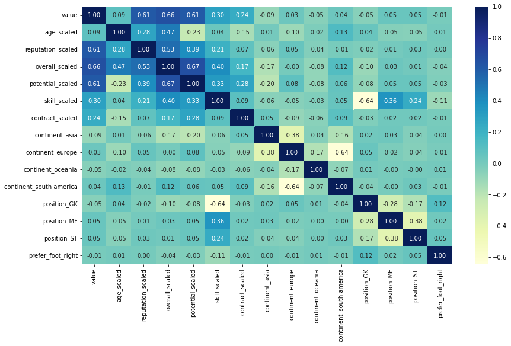

```python
#상관계수 시각화
import seaborn as sn
import matplotlib.pyplot as plt
plt.rcParams["figure.figsize"] = (14,8)
sn.heatmap(corr,annot=True,fmt=".2f",cmap="YlGnBu")
plt.show()
```

- 상관계수가 높은 reputation, overall_scaled, potential_scaled과 value의 산점도를 그려 관계를 파악

```python
import plotly.express as px

fig1 = px.scatter(y = pd.concat([X_train,y_train],axis=1)["value"],x = pd.concat([X_train,y_train],axis=1)["reputation_scaled"],trendline="ols")
fig2 = px.scatter(y = pd.concat([X_train,y_train],axis=1)["value"],x = pd.concat([X_train,y_train],axis=1)["potential_scaled"],trendline="ols")
fig3 = px.scatter(y = pd.concat([X_train,y_train],axis=1)["value"],x = pd.concat([X_train,y_train],axis=1)["overall_scaled"],trendline="ols")

#value-reputation_scaled scatter plot
fig1.show()

#value-potential_scaled scatter plot
fig2.show()

#value-overall_scaled scatter plot
fig3.show()
```

```
Output hidden; open in https://colab.research.google.com to view.
```

- 다수의 값이 최저값을 가지고있는 명성 변수는 회귀선이 이적료를 잘 설명한다고 할 수 없다.
- 잠재력 변수는 고르게 분포되어있어 명성 변수에 비해서 회귀선이 어느정도는 이적료를 잘 설명한다.
- 능력치 변수는 고르게 분포되어있어 명성 변수에 비해서 회귀선이 어느정도는 이적료를 잘 설명하고 세 변수 중 오차가 가장 적어보인다.

## 데이터 모델링

- 다중회귀분석(변수선택법) VS Lasso 회귀분석 VS 머신러닝

### 다중회귀분석(모든변수, stepwise, 후진제거법)

#### 모든 변수를 사용한 다중회귀분석

- 회귀분석은 관찰된 연속형 변수들에 대해 변수 사이의 모형을 구한 뒤 적합도를 측정해 내는 분석 방법이고, 이는 통계적 예측에 사용될 수 있다.

```python
#모든 변수를 집어넣어 회귀분석

import statsmodels.api as sm
model1 = sm.OLS(y_train, sm.add_constant(X_train_dum)).fit()
print(model1.summary())

# 결정계수 96.9% 다중공선성 문제 X
```

```
                            OLS Regression Results
==============================================================================
Dep. Variable:                  value   R-squared:                       0.969
Model:                            OLS   Adj. R-squared:                  0.969
Method:                 Least Squares   F-statistic:                 2.013e+04
Date:                Sun, 29 May 2022   Prob (F-statistic):               0.00
Time:                        04:40:08   Log-Likelihood:                -127.95
No. Observations:                8932   AIC:                             285.9
Df Residuals:                    8917   BIC:                             392.4
Df Model:                          14
Covariance Type:            nonrobust
===========================================================================================
                              coef    std err          t      P>|t|      [0.025      0.975]
-------------------------------------------------------------------------------------------
const                      13.7217      0.011   1229.330      0.000      13.700      13.744
age_scaled                 -0.4686      0.005    -86.470      0.000      -0.479      -0.458
reputation_scaled           0.0213      0.006      3.420      0.001       0.009       0.033
overall_scaled              1.5412      0.007    216.106      0.000       1.527       1.555
potential_scaled           -0.0417      0.006     -6.632      0.000      -0.054      -0.029
skill_scaled                0.0264      0.004      6.134      0.000       0.018       0.035
contract_scaled             0.0004      0.003      0.146      0.884      -0.005       0.006
continent_asia              0.0230      0.013      1.775      0.076      -0.002       0.048
continent_europe           -0.0133      0.010     -1.352      0.177      -0.033       0.006
continent_oceania          -0.0344      0.021     -1.651      0.099      -0.075       0.006
continent_south america     0.0019      0.011      0.179      0.858      -0.019       0.023
position_GK                -0.0837      0.011     -7.536      0.000      -0.106      -0.062
position_MF                 0.1247      0.007     17.955      0.000       0.111       0.138
position_ST                 0.1782      0.008     21.673      0.000       0.162       0.194
prefer_foot_right           0.0134      0.006      2.132      0.033       0.001       0.026
==============================================================================
Omnibus:                     2208.274   Durbin-Watson:                   1.219
Prob(Omnibus):                  0.000   Jarque-Bera (JB):            11494.908
Skew:                          -1.092   Prob(JB):                         0.00
Kurtosis:                       8.110   Cond. No.                         14.2
==============================================================================

Warnings:
[1] Standard Errors assume that the covariance matrix of the errors is correctly specified.
```

```python
lr1 = model1.predict(sm.add_constant(X_train_dum))
np.expm1(lr1) #모든변수 사용한 회귀분석 예측값
```

```
name
L. Messi              2.450750e+08
De Gea                1.298861e+08
L. Suárez             1.248764e+08
Sergio Ramos          9.246280e+07
J. Oblak              1.260462e+08
                          ...
S. Adewusi            3.191534e+04
C. Ehlich             1.995368e+04
N. Fuentes            2.165434e+04
J. Milli              1.882700e+04
N. Christoffersson    2.319113e+04
Length: 8932, dtype: float64
```

#### 후진제거법을 사용한 다중회귀분석

- 후진제거법은 설명변수 후보 모두를 포함한 모형에서 출발해 가장 적은 영향을 주는 변수부터 하나씩 제거하면서 더 이상 제거할 변수가 없을 때의 모형을 선택한다.

```python
## 후진제거법
def backward_regression(X, y, initial_list=[], threshold_out = 0.05, # P-value 임계값 (제거 기준)
 feature_list = X_train_dum.columns.tolist() ):


    sv_per_step = [] ## 각 스텝별로 선택된 변수들
    adj_r_squared_list = [] ## 각 스텝별 수정된 결정계수
    steps = [] ## 스텝
    step = 0
    included = feature_list
    while True:
       changed=False
       model = sm.OLS(y, sm.add_constant(pd.DataFrame(X[feature_list]))).fit(disp=0)
       # use all coefs except intercept
       pvalues = model.pvalues.iloc[1:] # 각 feature의 P값을 의미함
       worst_pval = pvalues.max() # P 값이 가장 높은 것 선정
       if worst_pval > threshold_out:
          changed=True
          worst_feature = pvalues.idxmax()
          included.remove(worst_feature)

       step += 1
       steps.append(step)
       adj_r_squared = sm.OLS(y, sm.add_constant(pd.DataFrame(X[feature_list]))).fit(disp=0).rsquared_adj
       adj_r_squared_list.append(adj_r_squared)
       sv_per_step.append(included.copy())

       if not changed:
         break

    return included,step,steps,adj_r_squared_list,sv_per_step


backward_valriables_function,step,steps,adj_r_squared_list,sv_per_step = backward_regression(X_train_dum, y_train)

print(backward_valriables_function)
```

```
['age_scaled', 'reputation_scaled', 'overall_scaled', 'potential_scaled', 'skill_scaled', 'continent_asia', 'continent_europe', 'position_GK', 'position_MF', 'position_ST', 'prefer_foot_right']
```

```python
model2 = sm.OLS(y_train, sm.add_constant(pd.DataFrame(X_train_dum[backward_valriables_function]))).fit(disp=0)
print(model2.summary())

# 후진제거법은 'age_scaled', 'reputation_scaled', 'overall_scaled', 'potential_scaled', 'skill_scaled', 'continent_asia', 'continent_europe', 'position_GK', 'position_MF', 'position_ST', 'prefer_foot_right' 총 11개 변수 사용
# 결정계수는 96.9% 모든 변수 유의수준 5% 이내에서 유의
```

```
                            OLS Regression Results
==============================================================================
Dep. Variable:                  value   R-squared:                       0.969
Model:                            OLS   Adj. R-squared:                  0.969
Method:                 Least Squares   F-statistic:                 2.562e+04
Date:                Sun, 29 May 2022   Prob (F-statistic):               0.00
Time:                        04:40:16   Log-Likelihood:                -129.71
No. Observations:                8932   AIC:                             283.4
Df Residuals:                    8920   BIC:                             368.6
Df Model:                          11
Covariance Type:            nonrobust
=====================================================================================
                        coef    std err          t      P>|t|      [0.025      0.975]
-------------------------------------------------------------------------------------
const                13.7207      0.008   1788.862      0.000      13.706      13.736
age_scaled           -0.4683      0.005    -87.647      0.000      -0.479      -0.458
reputation_scaled     0.0208      0.006      3.352      0.001       0.009       0.033
overall_scaled        1.5414      0.007    217.707      0.000       1.528       1.555
potential_scaled     -0.0412      0.006     -6.568      0.000      -0.053      -0.029
skill_scaled          0.0263      0.004      6.121      0.000       0.018       0.035
continent_asia        0.0244      0.010      2.399      0.016       0.004       0.044
continent_europe     -0.0124      0.006     -2.139      0.032      -0.024      -0.001
position_GK          -0.0840      0.011     -7.558      0.000      -0.106      -0.062
position_MF           0.1247      0.007     17.963      0.000       0.111       0.138
position_ST           0.1784      0.008     21.708      0.000       0.162       0.195
prefer_foot_right     0.0133      0.006      2.124      0.034       0.001       0.026
==============================================================================
Omnibus:                     2208.925   Durbin-Watson:                   1.218
Prob(Omnibus):                  0.000   Jarque-Bera (JB):            11495.048
Skew:                          -1.093   Prob(JB):                         0.00
Kurtosis:                       8.110   Cond. No.                         6.84
==============================================================================

Warnings:
[1] Standard Errors assume that the covariance matrix of the errors is correctly specified.
```

```python
lr2 = model2.predict(sm.add_constant(X_train_dum[backward_valriables_function]))
np.expm1(lr2) #후진제거법 예측값
```

```
name
L. Messi              2.449055e+08
De Gea                1.301312e+08
L. Suárez             1.247442e+08
Sergio Ramos          9.265427e+07
J. Oblak              1.262429e+08
                          ...
S. Adewusi            3.183719e+04
C. Ehlich             1.990885e+04
N. Fuentes            2.154736e+04
J. Milli              1.878543e+04
N. Christoffersson    2.315219e+04
Length: 8932, dtype: float64
```

#### 단계적선택법을 사용한 다중회귀분석

- 단계적선택법은 전진선택법에 의해 변수를 추가하면서 새롭게 추가된 변수에 기인해 기존 변수의 중요도가 약화되면 해당변수를 제거하는 등 단계별로 추가 또는 제거되는 변수의 여부를 검토해 더 이상 없을 때 중단하는 방식이다.

```python
def stepwise_feature_selection(X_train, y_train, variables=X_train_dum.columns.tolist() ):
   import statsmodels.api as sm
   import matplotlib.pyplot as plt
   import warnings
   warnings.filterwarnings("ignore")
   y = y_train ## 반응 변수
   selected_variables = [] ## 선택된 변수들
   sl_enter = 0.05
   sl_remove = 0.05
   sv_per_step = [] ## 각 스텝별로 선택된 변수들
   adjusted_r_squared = [] ## 각 스텝별 수정된 결정계수
   steps = [] ## 스텝
   step = 0
   while len(variables) > 0:
     remainder = list(set(variables) - set(selected_variables))
     pval = pd.Series(index=remainder) ## 변수의 p-value
     ## 기존에 포함된 변수와 새로운 변수 하나씩 돌아가면서
     ## 선형 모형을 적합한다.
     for col in remainder:
       X = X_train[selected_variables+[col]]
       X = sm.add_constant(X)
       model = sm.OLS(y,X).fit(disp=0)
       pval[col] = model.pvalues[col]

     min_pval = pval.min()
     if min_pval < sl_enter: ## 최소 p-value 값이 기준 값보다 작으면 포함
       selected_variables.append(pval.idxmin())
       ## 선택된 변수들에대해서
       ## 어떤 변수를 제거할지 고른다.
       while len(selected_variables) > 0:
         selected_X = X_train[selected_variables]
         selected_X = sm.add_constant(selected_X)
         selected_pval = sm.OLS(y,selected_X).fit(disp=0).pvalues[1:] ## 절편항의 p-value는 뺀다
         max_pval = selected_pval.max()
         if max_pval >= sl_remove: ## 최대 p-value값이 기준값보다 크거나 같으면 제외
           remove_variable = selected_pval.idxmax()
           selected_variables.remove(remove_variable)
         else:
             break

       step += 1
       steps.append(step)
       adj_r_squared = sm.OLS(y,sm.add_constant(X_train[selected_variables])).fit(disp=0).rsquared_adj
       adjusted_r_squared.append(adj_r_squared)
       sv_per_step.append(selected_variables.copy())
     else:
       break

   return selected_variables

selected_variables = stepwise_feature_selection(X_train_dum, y_train)

print(selected_variables)
```

```
['skill_scaled', 'potential_scaled', 'overall_scaled', 'age_scaled', 'position_ST', 'position_MF', 'position_GK', 'continent_asia', 'reputation_scaled', 'continent_south america', 'prefer_foot_right']
```

```python
model3 = sm.OLS(y_train, sm.add_constant(pd.DataFrame(X_train_dum[selected_variables]))).fit(disp=0)
print(model3.summary())

# stepwise 변수선택법은 'reputation_scaled', 'skill_scaled', 'potential_scaled', 'age_scaled', 'overall_scaled', 'position_ST', 'position_MF', 'position_GK', 'continent_asia', 'continent_south america', 'prefer_foot_right' 총 11개 변수를 사용했다.
# 결정계수는 96,9%이고 모든 변수는 유의수준 5% 이내에서 유의하다.
```

```
                            OLS Regression Results
==============================================================================
Dep. Variable:                  value   R-squared:                       0.969
Model:                            OLS   Adj. R-squared:                  0.969
Method:                 Least Squares   F-statistic:                 2.562e+04
Date:                Sun, 29 May 2022   Prob (F-statistic):               0.00
Time:                        04:40:25   Log-Likelihood:                -129.60
No. Observations:                8932   AIC:                             283.2
Df Residuals:                    8920   BIC:                             368.4
Df Model:                          11
Covariance Type:            nonrobust
===========================================================================================
                              coef    std err          t      P>|t|      [0.025      0.975]
-------------------------------------------------------------------------------------------
const                      13.7089      0.007   2058.737      0.000      13.696      13.722
skill_scaled                0.0265      0.004      6.160      0.000       0.018       0.035
potential_scaled           -0.0419      0.006     -6.663      0.000      -0.054      -0.030
overall_scaled              1.5419      0.007    217.650      0.000       1.528       1.556
age_scaled                 -0.4689      0.005    -87.356      0.000      -0.479      -0.458
position_ST                 0.1789      0.008     21.790      0.000       0.163       0.195
position_MF                 0.1248      0.007     17.978      0.000       0.111       0.138
position_GK                -0.0839      0.011     -7.555      0.000      -0.106      -0.062
continent_asia              0.0357      0.009      3.763      0.000       0.017       0.054
reputation_scaled           0.0209      0.006      3.366      0.001       0.009       0.033
continent_south america     0.0143      0.007      2.189      0.029       0.001       0.027
prefer_foot_right           0.0136      0.006      2.168      0.030       0.001       0.026
==============================================================================
Omnibus:                     2208.885   Durbin-Watson:                   1.218
Prob(Omnibus):                  0.000   Jarque-Bera (JB):            11500.255
Skew:                          -1.092   Prob(JB):                         0.00
Kurtosis:                       8.111   Cond. No.                         6.43
==============================================================================

Warnings:
[1] Standard Errors assume that the covariance matrix of the errors is correctly specified.
```

```python
lr3 = model3.predict(sm.add_constant(X_train_dum[selected_variables]))
np.expm1(lr3) #단계적선택법 예측값
```

```
name
L. Messi              2.454337e+08
De Gea                1.301108e+08
L. Suárez             1.250383e+08
Sergio Ramos          9.264349e+07
J. Oblak              1.262390e+08
                          ...
S. Adewusi            3.149543e+04
C. Ehlich             1.994078e+04
N. Fuentes            2.161158e+04
J. Milli              1.880124e+04
N. Christoffersson    2.318973e+04
Length: 8932, dtype: float64
```

```python
#각 모델들의 RMSE 평가

from sklearn.metrics import mean_squared_error
from math import sqrt
X_pred1 = np.expm1(lr1)
X_pred2 = np.expm1(lr2)
X_pred3 = np.expm1(lr3)

rmse1 = sqrt(mean_squared_error(np.expm1(y_train), X_pred1))
rmse2 = sqrt(mean_squared_error(np.expm1(y_train), X_pred2))
rmse3 = sqrt(mean_squared_error(np.expm1(y_train), X_pred3))

print("model1 rmse :", rmse1)
print("model2 rmse :", rmse2)
print("model3 rmse :", rmse3)
```

```
model1 rmse : 2625601.895279
model2 rmse : 2626562.383201663
model3 rmse : 2630333.8648211905
```

#### 결론

- 최종적으로 회귀분석의 세 모델의 결정계수는 96.9%로 동일하지만 모든 변수를 사용한 모델은 유의하지 않은 변수가 존재하였다.
- 변수선택법을 사용한 모델과 모든 변수를 사용한 모델의 RMSE 값에는 별다른 차이가 없었다.
- 동일한 결정계수를 가지고 있으면 더 적은 변수를 사용하는 것이 좋기에 model1보다는 model2와 model3를 사용하는 것이 더 좋을 것 같다.

### 다중회귀분석(Lasso)

- Lasso회귀를 사용하면 알파값에 따라 회귀계수가 0으로 수렴하여 feature selection의 효과를 가지기에 Lasso와 변수선택법의 성능을 비교해보았다.

```python
#lasso 회귀
from sklearn.linear_model import Lasso


alpha = [0.1,0.05,0.01,0.005,0.001,0.0005,0.0001]

for i in range(0,len(alpha)):
  lasso = Lasso(alpha = alpha[i]).fit(X_train_dum, y_train)
  print("훈련 세트의 정확도 : {:.2f}".format(lasso.score(X_train_dum, y_train)))
  print("사용한 특성의 수 : {}".format(np.sum(lasso.coef_ != 0)))
  print("사용한 max_iter : {}".format(lasso.n_iter_))
  la_pr = np.expm1(lasso.predict(X_train_dum))
  la_rmse = sqrt(mean_squared_error(np.expm1(y_train), la_pr))
  print("alpha: {}, rmse : {:.2f}".format(alpha[i], la_rmse),"\n\n")

# 가장 rmse가 작은 alpha값인 0.05를 사용하여 모델링한다.
```

```
훈련 세트의 정확도 : 0.93
사용한 특성의 수 : 4
사용한 max_iter : 40
alpha: 0.1, rmse : 1867984.23


훈련 세트의 정확도 : 0.96
사용한 특성의 수 : 4
사용한 max_iter : 40
alpha: 0.05, rmse : 1645610.65


훈련 세트의 정확도 : 0.97
사용한 특성의 수 : 5
사용한 max_iter : 40
alpha: 0.01, rmse : 2174226.32


훈련 세트의 정확도 : 0.97
사용한 특성의 수 : 6
사용한 max_iter : 26
alpha: 0.005, rmse : 2351573.36


훈련 세트의 정확도 : 0.97
사용한 특성의 수 : 12
사용한 max_iter : 46
alpha: 0.001, rmse : 2558737.89


훈련 세트의 정확도 : 0.97
사용한 특성의 수 : 13
사용한 max_iter : 52
alpha: 0.0005, rmse : 2592003.16


훈련 세트의 정확도 : 0.97
사용한 특성의 수 : 14
사용한 max_iter : 65
alpha: 0.0001, rmse : 2618589.40
```

```python
model_lasso = Lasso(alpha = 0.05)
model_lasso.fit(X_train_dum,y_train)

la_pr = np.expm1(model_lasso.predict(X_train_dum))
la_rmse = sqrt(mean_squared_error(np.expm1(y_train), la_pr))

print(la_rmse)
```

```
1645610.647501823
```

```python
from sklearn.model_selection import cross_val_score
from sklearn.model_selection import KFold

score = cross_val_score(model_lasso, X_train_dum, y_train, cv=KFold(n_splits = 10, shuffle = True,random_state=999))
print('cross val score : %s' %score) #1fold별 정확도
print('mean cv score : %.3f' %score.mean()) #교차검증 평균 정확도

# train data에 대한 교차검증 정확도는 95.9%
```

```
cross val score : [0.94953138 0.96056542 0.96726901 0.9645427  0.9594362  0.96014726
 0.94909073 0.9595766  0.95783274 0.95842263]
mean cv score : 0.959
```

```python
np.expm1(model_lasso.predict(X_test_dum))
```

```
array([1.96629466e+08, 1.92452358e+08, 1.34138692e+08, ...,
       3.55936755e+04, 2.68615428e+04, 2.54867991e+04])
```

#### 결론

- 교차검증의 수행 결과 Lasoo 모델의 평균 정확도는 95.9%로 나왔다.
- Lasso 모델과 변수선택 모델을 비교하면 Lasso 모델의 RMSE가 1645610으로 약 백만 정도의 차이를 보였다.
- Lasso 모델이 변수선택 모델보다 더 정확한 모델임을 알 수 있었다.

### 머신러닝 기법

- VotingRegressor
- ExtraTreesRegressor
- NGBRegressor
- GradientBoostionRegressor
- XGBRegressor
- LightGBMRegressor
- CatBoostRegressor
- 최종 예측값: 7개의 모델의 이적료 예측값의 평균값을 사용하였다.
- 하이퍼파라미터: 10분할 교차검증을 적용한 그리드 서치로 데이터에 가장 적합한 하이퍼파라미터를 찾아 각 모델에 적용하였다.
- 모델의 평가: RMSE(평균 제곱근 편차)

```python
#사이킷런 모듈에 포함되지 않은 외부 모듈의 모델을 불러온다.
!pip install ngboost
!pip install catboost
```

```python
#필요한 라이브러리 호출
from sklearn.model_selection import cross_val_score
from sklearn.model_selection import KFold
from sklearn.linear_model import LinearRegression
from sklearn.linear_model import Ridge
from sklearn.linear_model import Lasso
from sklearn.linear_model import ElasticNet
from sklearn.ensemble import VotingRegressor
from sklearn.model_selection import GridSearchCV
from ngboost import NGBRegressor
from sklearn.ensemble import GradientBoostingRegressor
from xgboost import XGBRegressor
from lightgbm import LGBMRegressor
from catboost import CatBoostRegressor
from sklearn.ensemble import ExtraTreesRegressor
```

```python
# cv값 설정
cv=KFold(n_splits = 10, shuffle = True,random_state=999)
```

#### VotingRegressor

- VotingRegressor는 서로 다른 알고리즘을 가진 모델을 결합하여 각각의 결과에 대해 투표로 최종 결과를 예측하는 모델이다.

```python
linear_reg = LinearRegression(n_jobs=-1)
linear_reg.fit(X_train_dum, y_train)
ridge = Ridge(alpha = 1)
ridge.fit(X_train_dum, y_train)
lasso = Lasso(alpha = 0.05)
lasso.fit(X_train_dum, y_train)
elasticnet = ElasticNet(alpha=0.5, l1_ratio=0.2)
elasticnet.fit(X_train_dum, y_train)
```

```
ElasticNet(alpha=0.5, l1_ratio=0.2)
```

```python
# VotingRegressor

# 보팅에 참여한 single models 지정
single_models = [
    ('linear_reg', linear_reg),
    ('ridge', ridge),
    ('lasso', lasso),
    ('elasticnet', elasticnet),
]
```

```python
# voting regressor 만들기
vtr = VotingRegressor(single_models, n_jobs=-1)
vtr.fit(X_train_dum, y_train)

score = cross_val_score(vtr, X_train_dum, y_train, cv=KFold(n_splits = 10, shuffle = True,random_state=999))
print('cross val score : %s' %score,"\n") #1fold별 정확도
print('mean cv score : %.3f' %score.mean(),"\n") #교차검증 평균 정확도

vote_pr = np.expm1(vtr.predict(X_train_dum))
vote_rmse = sqrt(mean_squared_error(np.expm1(y_train), vote_pr))
print("rmse : {:.2f}".format(vote_rmse))


#교차검증 정확도 95.9% RMSE: 1397093
```

```
cross val score : [0.95211821 0.96081299 0.9663123  0.96445774 0.95973625 0.96084981
 0.95157687 0.95970659 0.95970234 0.95859701]

mean cv score : 0.959

rmse : 1397093.00
```

```python
# y_test 예측
vt_pred = np.expm1(vtr.predict(X_test_dum))
print(vt_pred)
```

```
[1.60561207e+08 1.72380660e+08 1.17285060e+08 ... 4.22283542e+04
 3.32924213e+04 3.09753984e+04]
```

#### ExtraTreesRegressor

- ExtraTrees 모델은 랜덤포레스트 모델과 닮아있지만 조금 더 극단적으로 랜덤하게 만든 모델이다.
- 사용한 하이퍼파라미터는 max_depth, n_estimators, min_sample_split이다.

```python
etr = ExtraTreesRegressor()

parameters = {"n_estimators": [50, 100, 200, 500, 1000],
              "max_depth": [3, 5, 7, 9, 11],
              'min_samples_split':[2, 3, 5, 7, 9],
                   }

grid_search = GridSearchCV(estimator=etr,
                           param_grid=parameters,
                           n_jobs=-1,
                           cv = cv
                          )

grid_search.fit(X_train_dum, y_train)
grid_search.best_params_ # 'max_depth': 11, 'min_samples_split': 2, 'n_estimators': 1000
```

```python
etr = ExtraTreesRegressor(max_depth = 11,
                            min_samples_split = 2,
                            n_estimators = 1000,
                            random_state=999)
etr.fit(X_train_dum, y_train)
```

```
ExtraTreesRegressor(max_depth=11, n_estimators=1000, random_state=999)
```

```python
score = cross_val_score(etr, X_train_dum, y_train, cv=KFold(n_splits = 10, shuffle = True,random_state=999))
print('cross val score : %s' %score,"\n") #1fold별 정확도
print('mean cv score : %.3f' %score.mean(),"\n") #교차검증 평균 정확도

et_pr = np.expm1(etr.predict(X_train_dum))
et_rmse = sqrt(mean_squared_error(np.expm1(y_train), et_pr))
print("rmse : {:.2f}".format(et_rmse))

#교차검증 정확도 99.4%, rmse : 316062
```

```
cross val score : [0.9928485  0.99411514 0.99563787 0.99492411 0.99471433 0.99474718
 0.99326335 0.99408959 0.99469033 0.99475257]

mean cv score : 0.994

rmse : 316062.21
```

```python
# y_test 예측
et_pred = np.expm1(etr.predict(X_test_dum))
print(et_pred)
```

```
[7.47211120e+07 8.67878727e+07 6.28194926e+07 ... 5.79132468e+04
 4.98541240e+04 5.28615374e+04]
```